# Heston & SABR: YUIMA

R. Dance

[Link to YUIMA book, see page 85](https://doi.org/10.1007/978-3-319-55569-0) [Link to reference used in this notebook](https://qfinatwork.com/public/qfin/files/Stefano_Iacus.pdf) Saved in files “YUIMA_Stefano_Iacus.pdf”

```r
library(yuima)
```

## 1D Unparametrised SDE

A simple 1D SDE model for starters with numerical coefficients: $dX_t = -3X_t dt + \frac{1}{1+X_t^2}$

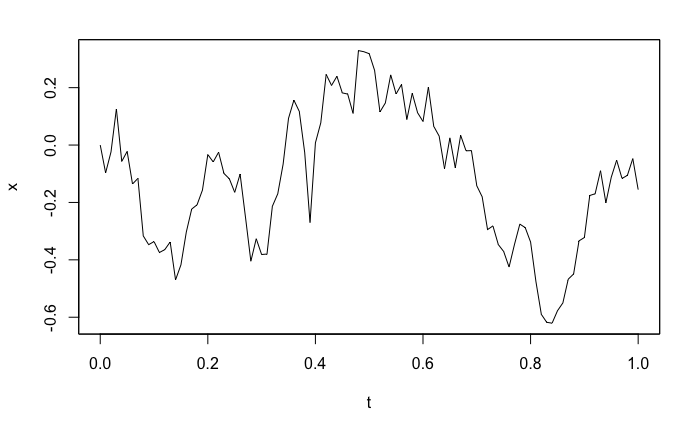

```r
mod1 <- setModel(drift = "-3*x", diffusion = "1/(1+x^2)")
set.seed(123)
X <- simulate(mod1)
plot(X)
```

Spit out all of the YUIMA model details… (there’s a lot so commented it out)

```r
#str(X)
```

Summary of X:

```r
X
```

```
Diffusion process
Number of equations: 1
Number of Wiener noises: 1

Number of original time series: 1
length = 101, time range [0 ; 1]

Number of zoo time series: 1
```

|  | length | time.min | time.max | delta |
| --- | --- | --- | --- | --- |
| Series 1 | 101 | 0 | 1 | 0.01 |

## Parametrised model

This time the model has parameters, $\theta$ and $\gamma$: $dX_t = -\theta X_t dt + \frac{1}{1+X_t^\gamma} dW_t$

```r
mod2 <- setModel(drift = "-theta*x", diffusion = "1/(1+x^gamma)")
mod2
```

```
Diffusion process
Number of equations: 1
Number of Wiener noises: 1
Parametric model with 2 parameters
```

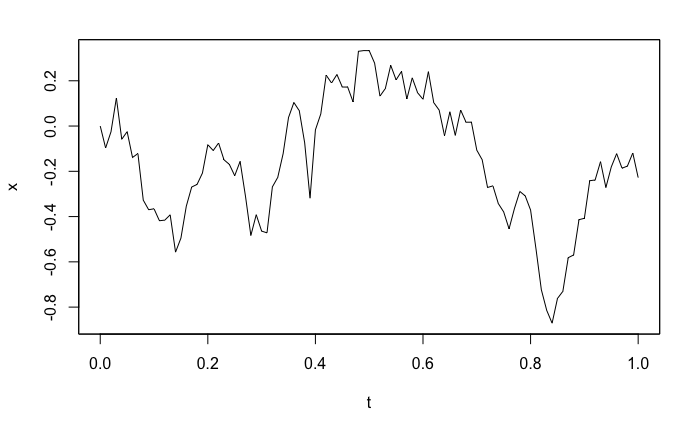

```r
set.seed(123)
plot(simulate(mod2,true.parameter =list(theta=1,gamma=3)))
```

## Parametrised 1D SDE model, with QMLE - Ornstein Uhlenbeck 1D results

So we want to recover our parameter estimates from their true values. $dX_t = \theta_1(\theta_2 - X_t) dt + \theta_3dW_t$

```r
diff.matrix <- matrix(c("theta3"), 1, 1) #so apparently dots are ok in names in R... weird.
ymodel <- setModel(drift = c("theta1*(theta2-x)"), diffusion = diff.matrix, time.variable = "t", state.variable = "x", solve.variable = "x")
# here you can do plot(simulate(ymodel,true.parameter =list(theta=0.3,gamma=0.1))) to show specific paths at given input params.
# ...this is where the qMLE things specific begin...
n <-100
ysamp <- setSampling(Terminal = (n)^(1/3), n = n) #this expression seems rather arbitrary, 100^1/3 = 4.6?!
yuima <- setYuima(model = ymodel, sampling = ysamp) #yuima - name of package or a variable now?
set.seed(123)
#True values of parameters specified for simulation here, but stay unknown to yuima object?
yuima <- simulate(yuima, xinit = 0.1, true.parameter = list(theta1 = 1.0, theta2 = 0.1, theta3=0.2))
# now call qmle on yuima object
mle1 <- qmle(yuima, start = list(theta1 = 0.05, theta2 = 0.05,theta3=0.05), lower = list(theta1=0.001, theta2=0.001,theta3=0.001), upper = list(theta1=5, theta2=1,theta3=1), method = "L-BFGS-B")
#print result - can also use just coef(mle1)
summary(mle1)
```

```
Quasi-Maximum likelihood estimation

Call:
qmle(yuima = yuima, start = list(theta1 = 0.05, theta2 = 0.05,
    theta3 = 0.05), method = "L-BFGS-B", lower = list(theta1 = 0.001,
    theta2 = 0.001, theta3 = 0.001), upper = list(theta1 = 5,
    theta2 = 1, theta3 = 1))

Coefficients:
         Estimate Std. Error
theta3 0.20051757 0.01463079
theta1 1.90564683 0.90135834
theta2 0.05611752 0.04887049

-2 log L: -348.8355
```

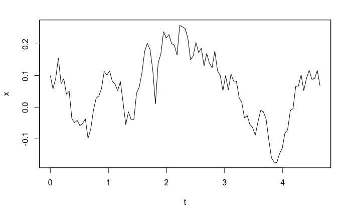

```r
plot(yuima)
```

## 2D parametric Model with qMLE (2-dimensional diffusions with 3 noises)

$dX_t^{(1)} = -\theta_2X_t^{(1)}*dt + dW_t^{(1)} + X_t^{(2)}*dW_t^{(3)}$ $dX_t^{(2)} = -(X_t^1 + \theta_1 X_t^{(2)})dt + X_t^1dW_t^{(1)} + \theta_2dW_t^{(2)}$

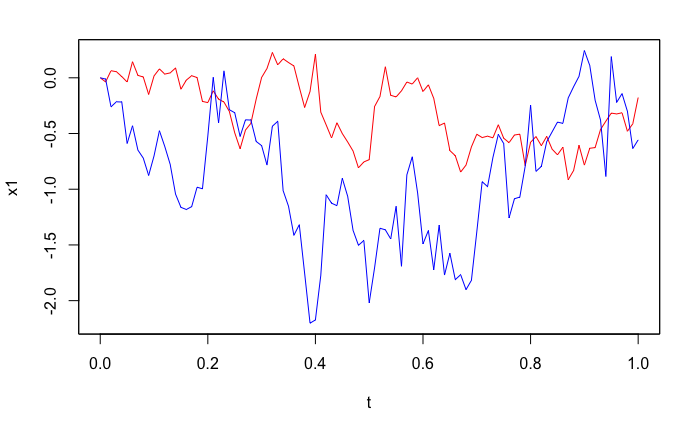

```r
sol <- c("x1","x2") # variable for numerical solution
drifts <- c("-theta2*x1","-x1 - theta1*x2") # drift vectors
diffs <- matrix(c("1","x1","0","theta2","x2","0"),2,3) # diffusion matrix
mod3 <- setModel(drift = drifts, diffusion = diffs, solve.variable = sol,time.variable="t", state.variable = sol)
#plotting for 2D on one plot slightly different:
plot(simulate(mod3, true.parameter = list(theta1=2, theta2=3)), plot.type="single", col=c("red","blue"))
```

My main concern here is that I *havent* specified any kind of correlation. This is just two independent processes working away???

```r
n <- 100
mod3samp <- setSampling(Terminal = (n)^(1/3),n = n)
mod3yuima <- setYuima(model=mod3, sampling = mod3samp)
set.seed(123)
mod3yuima <- simulate(mod3yuima, xinit=1, true.parameter = list(theta1 = 2,theta2 = 3)) # X is a yuima object
# plot(X,plot.type="single",col=c("red","blue"))
mle_mod3 <-qmle(mod3yuima, start = list(theta1 = 1.0, theta2 = 1.0),lower = list(theta1=0.05, theta2=0.05), upper = list(theta1=4, theta2=6))
summary(mle_mod3)
```

```
Quasi-Maximum likelihood estimation

Call:
qmle(yuima = mod3yuima, start = list(theta1 = 1, theta2 = 1),
    lower = list(theta1 = 0.05, theta2 = 0.05), upper = list(theta1 = 4,
        theta2 = 6))

Coefficients:
       Estimate Std. Error
theta2 3.055640  0.2191145
theta2 3.055640  0.0000000
theta1 3.195416  1.1142626

-2 log L: 239.7203
```

Why have I got a third parameter? Why is there two theta2?!?!?

## Heston from the YUIMA book (it has correlation done properly, added qMLE)

$dX_t^{(1)} = \mu X_t^{(1)}dt + \sqrt{X_t^{(2)}}X_t^{(1)}dW_t^{(1)}$

$dX_t^{(2)} = k(\theta - X_t^{(2)})dt + \epsilon\sqrt{X_t^{(2)}}dW_t^{(2)}$

where the Brownians are correlated by some $\rho$ and lets say that we want to use two independent brownians $B_t^{(1)}$ and $B_t^{(2)}$ In order to do this, we need to transform them Cholesky decomposition (Colin, I used a package here!).

The joint distribution of these things (Y) wants to be bivariate normal with correlation matrix $\Sigma$ s.t. $Y\sim N(0,\Sigma)$. So we use Cholesky to find such a matrix that $A^TA=\Sigma$. Then if Z is the standard multivariate normal, then $AZ \sim N(0,\Sigma)$ in the same way as we change brownians to be $\sqrt{dt}.N(0,1)$ all the time. So if we take the correlation matrix, and get the Cholesky decomp of it to get A, we can transform (multiply in normal speak!) the original diffusion matrix so that it works with independent Brownians.

```r
rho = 0.7
Sigma <- matrix(c(0.5, rho, rho, 2.0), 2, 2) #I used own values from correlated wieners in python here so S_11 = S_22 = 1 ??
A <- chol(Sigma) # the decomposition
A
```

```
          [,1]      [,2]
[1,] 0.7071068 0.9899495
[2,] 0.0000000 1.0099505
```

```r
crossprod(A) # check to see if we get our input back
```

```
     [,1] [,2]
[1,]  0.5  0.7
[2,]  0.7  2.0
```

So now we rewrite, but multiply the diffusions by the matrix A to get our correlation as per Cholesky…

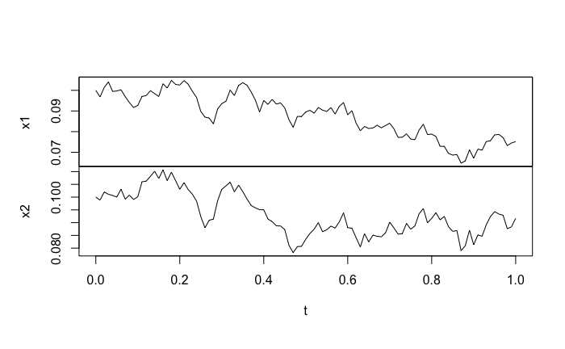

```r
set.seed(123)
drift_heston <- c("mu*x1", "kappa*(theta-x2)")
diff_heston <- matrix(c("c11*sqrt(x2)*x1", "0", "c12*sqrt(x2)*x1", "c22*epsilon*sqrt(x2)"),2,2)
heston <- setModel(drift=drift_heston, diffusion=diff_heston, state.var=c("x1","x2"))
X_heston <- simulate(heston, true.par=list(theta=0.1, mu=0.1, kappa=2,epsilon=0.1, c11=A[1,1], c12=A[1,2], c22=A[2,2]), xinit=c(0.1,0.1))
plot(X_heston) #,plot.type="single", col=c("red","blue") <- add this for a laugh
```

Now the QMLE bit for our Heston model…

```r
n <- 750
heston_samp <- setSampling(Terminal = n^(1/3), n=n)
yuima_heston <- setYuima(model=heston, sampling = heston_samp)
set.seed(123)
yuima_heston <- simulate(heston, true.parameter = list(theta=0.1, mu=0.1, kappa=2,epsilon=0.1, c11=A[1,1], c12=A[1,2], c22=A[2,2]))
param.init <- list(theta=0.5, mu=0.12, kappa=2,epsilon=0.2, c11=A[1,1], c12=A[1,2], c22=A[2,2])
# +- 1%
low.par <- list(theta=0, mu=0, kappa=0,epsilon=0, c11=A[1,1]*0.99, c12=A[1,2]*0.99, c22=A[2,2]*0.99)
upp.par <- list(theta=1, mu=1, kappa=5,epsilon=1, c11=A[1,1]*1.01, c12=A[1,2]*1.01, c22=A[2,2]*1.01)
mle_heston <- qmle(X_heston, start = param.init, lower = low.par, upper = upp.par)
```

[output not shown]

[output cut: 13 more lines]

[output not shown]

```r
summary(mle_heston)
```

```
Quasi-Maximum likelihood estimation

Call:
qmle(yuima = X_heston, start = param.init, lower = low.par, upper = upp.par)

Coefficients:
         Estimate Std. Error
c11     0.7141778 0.03445578
c12     0.9800500 0.24379467
c22     0.9998510        NaN
epsilon 0.3824938        NaN
mu      0.0000000 0.21709192
kappa   0.0000000 0.00000000
theta   0.0000000        NaN

-2 log L: -1576.434
```

```r
recoveredSigma <- matrix(c(1.01,0, 0.693, 0.7070014), 2, 2)
recoveredRho <- crossprod(recoveredSigma)
recoveredRho
```

```
        [,1]    [,2]
[1,] 1.02010 0.69993
[2,] 0.69993 0.98010
```

```r
A
```

```
          [,1]      [,2]
[1,] 0.7071068 0.9899495
[2,] 0.0000000 1.0099505
```

```r
alphabets <- matrix(c(1,2, 3, 4), 2, 2)
alphabets
```

```
     [,1] [,2]
[1,]    1    3
[2,]    2    4
```

```r
alphabets[2,1]
```

```
[1] 2
```

```r
logLik(mle_heston)
```

```
'log Lik.' 788.2172 (df=7)
```

#### Colins email: Heston

```r
Sigma <- matrix(c(0.5, 0.7, 0.7, 2), 2, 2)
C <- chol(Sigma)
C
```

```
          [,1]      [,2]
[1,] 0.7071068 0.9899495
[2,] 0.0000000 1.0099505
```

```r
## [,1] [,2]
## [1,] 0.7071068 0.9899495
## [2,] 0.0000000 1.0099505
crossprod(C)
```

```
     [,1] [,2]
[1,]  0.5  0.7
[2,]  0.7  2.0
```

```r
## [,1] [,2]
## [1,] 0.5 0.7
## [2,] 0.7 2.0
Sigma
```

```
     [,1] [,2]
[1,]  0.5  0.7
[2,]  0.7  2.0
```

```r
## [,1] [,2]
## [1,] 0.5 0.7
## [2,] 0.7 2.0
set.seed(123)
drift <- c("mu*x1", "kappa*(theta-x2)")
diffusion <- matrix(c("c11*sqrt(x2)*x1", "0",
"c12*sqrt(x2)*x1", "c22*epsilon*sqrt(x2)"),2,2)
heston <- setModel(drift=drift, diffusion=diffusion,
state.var=c("x1","x2"))
X <- simulate(heston, true.par=list(theta=0.5, mu=1.2, kappa=2,
epsilon=0.2, c11=C[1,1], c12=C[1,2], c22=C[2,2]),
xinit=c(10,0.1))
param.init <- list(theta=0.5, mu=0.5, kappa=0.5,epsilon=0.5,c11=0.5,c12=0.5,c22=0.5)
low.par <- list(theta=0, mu=0, kappa=0,epsilon=0)
upp.par <- list(theta=1, mu=1,kappa=1,epsilon=1)
mle1 <- qmle(X, start = param.init)
summary(mle1)
```

```
Quasi-Maximum likelihood estimation

Call:
qmle(yuima = X, start = param.init)

Coefficients:
         Estimate Std. Error
c11     0.7414469 0.05813131
c12     0.9328303 0.10177971
c22     0.3254958        NaN
epsilon 0.6641406        NaN
mu      0.7254040 0.61871341
kappa   2.6461987 0.78028585
theta   0.4246314 0.06235872

-2 log L: -483.08
```

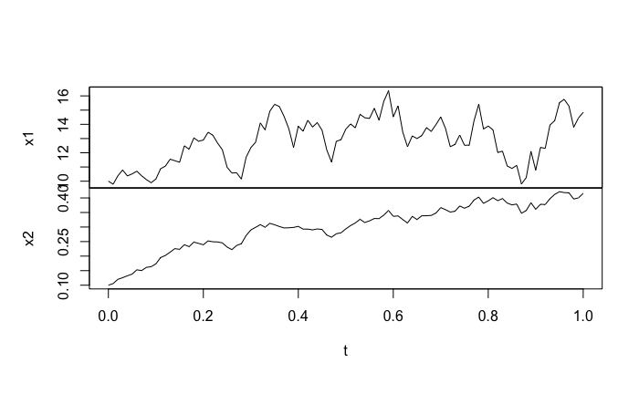

```r
plot(X)
```

### SABR…(modified heston from above)

$dX_t^{(1)} = X_t^{(2)} X_t^{(1)\beta}dW_t^{(1)}$

$dX_t^{(2)} = \alpha\: X_t^{(2)}dW_t^{(2)}$

where the brownians are correlated by some $\rho$ and lets say that we want to use two independent brownians $B_t^{(1)}$ and $B_t^{(2)}$ In order to do this, we need to transform them Cholesky decomposition (Colin, I used a package here!).

The joint distribution of these things (Y) wants to be bivariate normal with correlation matrix $\Sigma$ s.t. $Y\sim N(0,\Sigma)$. So we use Cholesky to find such a matrix that $A^TA=\Sigma$. Then if Z is the standard multivariate normal, then $AZ \sim N(0,\Sigma)$ in the same way as we change brownians to be $\sqrt{dt}.N(0,1)$ all the time. So if we take the correlation matrix, and get the Cholesky decomp of it to get A, we can transform (multiply in normal speak!) the original diffusion matrix so that it works with independent Brownians.

So the matrix form of the model as it stands is BLAH.

```r
rho = 0.2
Sigma <- matrix(c(0.5, rho, rho, 2.0), 2, 2) #I used own values from correlated wieners in python here so S_11 = S_22 = 1 ??
A <- chol(Sigma) # the decomposition
A
```

```
          [,1]      [,2]
[1,] 0.7071068 0.2828427
[2,] 0.0000000 1.3856406
```

```r
crossprod(A) # check to see if we get our input back
```

```
     [,1] [,2]
[1,]  0.5  0.2
[2,]  0.2  2.0
```

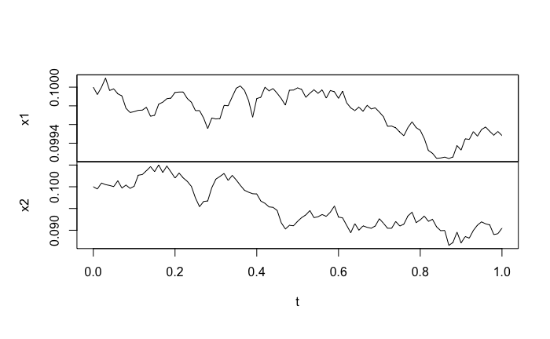

```r
set.seed(123)
drift_sabr <- c("0", "0")
diff_sabr <- matrix(c("x2*x1^beta*c11", "0", "x2*x1^beta*c12", "alpha*x2*c22"),2,2)
sabr <- setModel(drift=drift_sabr, diffusion=diff_sabr, state.var=c("x1","x2"))
X_sabr <- simulate(sabr, true.parameter=list(alpha=0.1,beta=2, c11=A[1,1], c12=A[1,2], c22=A[2,2]), xinit=c(0.1,0.1))
plot(X_sabr) #,plot.type="single", col=c("red","blue") <- add this for a laugh
```

```r
xt_R <- get.zoo.data(X_sabr)[[1]]
write(xt_R,'xt_R.csv')
vt_R <- get.zoo.data(X_sabr)[[2]]
write(vt_R,'vt_R.csv')
```

Now the qMLE bit…

```r
# n <- 750
# sabr_samp <- setSampling(Terminal = n^(1/3), n=n)
# yuima_sabr <- setYuima(model=sabr, sampling = sabr_samp)
# set.seed(123)
# yuima_sabr <- simulate(sabr, true.parameter=list(alpha=0.1,beta=1, c11=A[1,1], c12=A[1,2], c22=A[2,2]))
param.init <- list(alpha=0.1,beta=2, c11=A[1,1], c12=A[1,2], c22=A[2,2])
# +- 1% on the covariance matrix or it moans at you
low.par <- list(alpha=0.0,beta=-3, c11=A[1,1]*0.99, c12=A[1,2]*0.99, c22=A[2,2]*0.99)
upp.par <- list(alpha=1.0,beta=3, c11=A[1,1]*1.01, c12=A[1,2]*1.01, c22=A[2,2]*1.01)
mle_sabr <- qmle(X_sabr, start = param.init, lower = low.par, upper = upp.par)
summary(mle_sabr)
```

```
Quasi-Maximum likelihood estimation

Call:
qmle(yuima = X_sabr, start = param.init, lower = low.par, upper = upp.par)

Coefficients:
       Estimate Std. Error
beta  2.0122303        NaN
c11   0.7141778        NaN
c12   0.2800143        NaN
alpha 0.1018266 0.08736276
c22   1.3852774 1.19530131

-2 log L: -2680.312
```

```r
recoveredSigma <- matrix(c(0.714778,0, 0.2800143, 1.3852821), 2, 2)
recoveredRho <- crossprod(recoveredSigma)
recoveredRho
```

```
          [,1]      [,2]
[1,] 0.5109076 0.2001481
[2,] 0.2001481 1.9974145
```

```r
alphabets <- matrix(c(1,2, 3, 4), 2, 2)
alphabets
```

```
     [,1] [,2]
[1,]    1    3
[2,]    2    4
```

```r
alphabets[2,1]
```

```
[1] 2
```

Ok….

```r
logLik(mle_sabr)
```

```
'log Lik.' 1340.156 (df=5)
```

… there you have it.

The parameters seem to be just what the guesses are. That behaviour also doesnt seem to affect the MLE thats it gives out. If we set the true $\beta = -0.1$, and guess it as 0, it comes back as 0, for example.

I dont have time to dig into this a whole heap right now, but im curious as to why it behaves that way, but working out whether its a R thing, a YUIMA thing, or the probable ‘user error’, im not sure.

## Page 87 of the YUIMA DOCS (colins email)

$dXt^e = - drift.matrix * Xt^e * dt + diff.matrix * dWt$

```r
diff.matrix <- matrix(c("theta1.1","theta1.2", "1", "1"), 2, 2)
drift.c <- c("-theta2.1*x1", "-theta2.2*x2", "-theta2.2", "-theta2.1")
drift.matrix <- matrix(drift.c, 2, 2)

ymodel <- setModel(drift=drift.matrix, diffusion=diff.matrix, time.variable="t",
state.variable=c("x1", "x2"), solve.variable=c("x1", "x2"))
n <- 100
ysamp <- setSampling(Terminal=(n)^(1/3), n=n)
yuima <- setYuima(model=ymodel, sampling=ysamp)
set.seed(123)

#.... from here
##xinit=c(x1, x2) #true.parameter=c(theta2.1, theta2.2, theta1.1, theta1.2)
yuima <- simulate(yuima, xinit=c(1, 1),
true.parameter=list(theta2.1=0.5, theta2.2=0.3, theta1.1=0.6, theta1.2=0.2))
## theta2 <- c(0.8, 0.2) #c(theta2.1, theta2.2) # THIS IS ALL COMMENTED OUT?!
##theta1 <- c(0.7, 0.1) #c(theta1.1, theta1.2)
## QL <- ql(yuima, theta2, theta1, h=1/((n)^(2/3))) #ql is real value of ()?
## QL
## ## another way of parameter specification
## #param <- list(theta2=theta2, theta1=theta1)
## #QL <- ql(yuima, h=1/((n)^(2/3)), param=param)
## #QL
## theta2.1.lim <- c(0, 1) #c is combine
## theta2.2.lim <- c(0, 1)
## theta1.1.lim <- c(0, 1)
## theta1.2.lim <- c(0, 1)
## theta2.lim <- t( matrix( c(theta2.1.lim, theta2.2.lim), 2, 2) ) #t is transpose
## theta1.lim <- t( matrix( c(theta1.1.lim, theta1.2.lim), 2, 2) )
## system.time(
## opt <- ml.ql(yuima, theta2, theta1, h=1/((n)^(2/3)), theta2.lim, theta1.lim)
## )
## opt@coef
system.time(
opt2 <- qmle(yuima, start=list(theta2.1=0.8, theta2.2=0.2, theta1.1=0.7, theta1.2=0.1),
lower=list(theta1.1=.1,theta1.2=.1,theta2.1=.1,theta2.2=.1),
upper=list(theta1.1=4,theta1.2=4,theta2.1=4,theta2.2=4), method="L-BFGS-B")
)
```

```
   user  system elapsed
  0.977   0.005   0.991
```

```r
opt2@coef
```

```
 theta1.1  theta1.2  theta2.1  theta2.2
0.5383560 0.1058174 1.0444789 0.7839499
```

```r
summary(opt2)
```

```
Quasi-Maximum likelihood estimation

Call:
qmle(yuima = yuima, start = list(theta2.1 = 0.8, theta2.2 = 0.2,
    theta1.1 = 0.7, theta1.2 = 0.1), method = "L-BFGS-B", lower = list(theta1.1 = 0.1,
    theta1.2 = 0.1, theta2.1 = 0.1, theta2.2 = 0.1), upper = list(theta1.1 = 4,
    theta1.2 = 4, theta2.1 = 4, theta2.2 = 4))

Coefficients:
          Estimate Std. Error
theta1.1 0.5383560  0.1176579
theta1.2 0.1058174  0.1104829
theta2.1 1.0444789  0.4122488
theta2.2 0.7839499  0.3465195

-2 log L: -229.9835
```

### SABR part 2 (pg81-2 of docs applied to SABR)

Applying the above to SABR

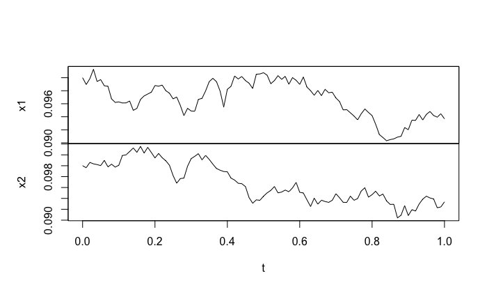

```r
rho = 0.2
Sigma <- matrix(c(1.0, rho, rho, 1.0), 2, 2) #I used own values from correlated wieners in python here so S_11 = S_22 = 1 ??
A <- chol(Sigma) # the decomposition

set.seed(123)
drift_sabr <- c("0", "0")
diff_sabr <- matrix(c("x2*x1^beta*c11", "0", "x2*x1^beta*c12", "alpha*x2*c22"),2,2)
sabr <- setModel(drift=drift_sabr, diffusion=diff_sabr, state.var=c("x1","x2"))
X_sabr <- simulate(sabr, true.parameter=list(alpha=0.1,beta=1, c11=A[1,1], c12=A[1,2], c22=A[2,2]), xinit=c(0.1,0.1))
plot(X_sabr) #,plot.type="single", col=c("red","blue") <- add this for a laugh
```

```r
n <- 750
sabr_samp <- setSampling(Terminal = n^(1/3), n=n)
yuima_sabr <- setYuima(model=sabr, sampling = sabr_samp)
set.seed(123)
yuima_sabr <- simulate(sabr, true.parameter=list(alpha=0.1,beta=-0.1, c11=A[1,1], c12=A[1,2], c22=A[2,2]))
param.init <- list(alpha=0.08,beta=0.5, c11=A[1,1], c12=A[1,2], c22=A[2,2])
low.par <- list(alpha=0.0,beta=-1, c11=A[1,1]*0.99, c12=A[1,2]*0.99, c22=A[2,2]*0.99)
upp.par <- list(alpha=1.0,beta=1.0, c11=A[1,1]*1.01, c12=A[1,2]*1.01, c22=A[2,2]*1.01)
system.time(
opt2 <- qmle(X_sabr, start = param.init,lower=low.par, upper = upp.par, method="L-BFGS-B")
)
```

```
   user  system elapsed
  1.877   0.037   1.954
```

```r
opt2@coef
```

```
     beta       c11       c12     alpha       c22
1.0000000 0.9900000 0.1980000 0.1025842 0.9715804
```

```r
summary(opt2)
```

```
Quasi-Maximum likelihood estimation

Call:
qmle(yuima = X_sabr, start = param.init, method = "L-BFGS-B",
    lower = low.par, upper = upp.par)

Coefficients:
       Estimate Std. Error
beta  1.0000000        NaN
c11   0.9900000        NaN
c12   0.1980000        NaN
alpha 0.1025842 0.09179581
c22   0.9715804 0.87427336

-2 log L: -2219.346
```

```r
opt2
```

```
Call:
qmle(yuima = X_sabr, start = param.init, method = "L-BFGS-B",
    lower = low.par, upper = upp.par)

Coefficients:
     beta       c11       c12     alpha       c22
1.0000000 0.9900000 0.1980000 0.1025842 0.9715804
```

```r
logLik(opt2)
```

```
'log Lik.' 1109.673 (df=5)
```

```r
recoveredSigma <- matrix(c(0.99, 0.198, 0, 0.9715804), 2, 2)
recoveredRho <- crossprod(recoveredSigma)
recoveredRho
```

```
          [,1]      [,2]
[1,] 1.0193040 0.1923729
[2,] 0.1923729 0.9439685
```

```r
toLatex(X_sabr)
```

```
%%% Copy and paste the following output in your LaTeX file
$$
\left(\begin{array}{c}
 dx1  \\  dx2  \\
 \end{array}\right)
 =
\left(\begin{array}{c}
 0 \\
 0 \\
 \end{array}\right) dt
 +
\left[\begin{array}{cc}
 x2  \cdot  x1^\beta   \cdot  c11&x2  \cdot  x1^\beta   \cdot  c12 \\
 0&\alpha   \cdot  x2  \cdot  c22 \\
 \end{array}\right]
\left(\begin{array}{c}
 dW1\\ dW2
 \end{array}\right)
$$
$$
\left(\begin{array}{c}
 x1(0)=. \\
 x2(0)=. \\
 \end{array}\right)
$$
```

## Page 81-2 YUIMA DOCS

(this is where we got wires crossed with docs and book so this is an extra) A different approach to putting in a 2D model into YUIMA. Its in the poisson.random.sampling method section, but its of the SABR type. Manual classification of the diffusion matrix, so it skips the Cholesky decomp calculation done for previous examples.

$dX_t^{(2)} = X_t^{(2)}(1+t) dW_t^{(2)}$ (book)

$dX_t^{(1)} = X_t^{(1)}\sqrt{(1+t^2)} dW_t^{(1)}$ (book)

$\rho = \sqrt{1+\frac{1}{2}\cos(X_t^{(1)}X_t^{(2)})}$ (book)

The code from pg 81-82 as it is…(with added plot)

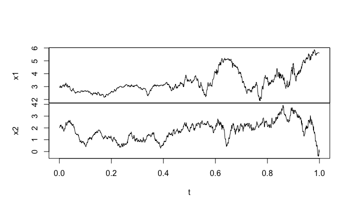

```r
## Set a model
diff.coef.1 <- function(t, x1=0, x2) x2*(1+t)
diff.coef.2 <- function(t, x1, x2=0) x1*sqrt(1+t^2)
cor.rho <- 0.7 #function(t, x1=0, x2=0) sqrt((1+cos(x1*x2))/2)
# Manual Cholesky matrix:
diff.coef.matrix <- matrix(c("diff.coef.1(t,x1,x2)","diff.coef.2(t,x1,x2)*cor.rho", "", "diff.coef.2(t,x1,x2)*sqrt(1-cor.rho^2)"),2,2)
cor.mod <- setModel(drift=c("",""), diffusion=diff.coef.matrix, solve.variable=c("x1", "x2"))
set.seed(111)

## Simulate & plot the two dimensional diffusion model
yuima.samp <- setSampling(Terminal=1, n=1200)
yuima <- setYuima(model=cor.mod, sampling=yuima.samp)
yuima <- simulate(yuima, xinit=c(3,2))
plot(yuima)
```

### Applied to SABR (docs pg81-2)

Answer looks sensible, I dont think I can apply an MLE here as there are no parameters? So applying this to SABR and adding an MLE…

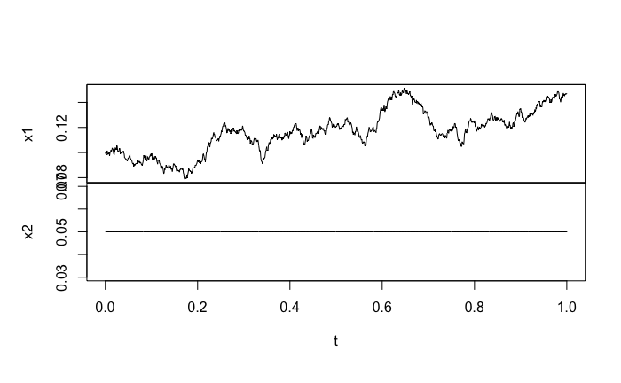

```r
# Set for SABR
library(yuima)
cor.rho <- 0.7
## Set a model
diff.coef.1 <- function(x1, x2,alpha, beta=1) x2 * x1^(beta)
diff.coef.2 <- function(x1, x2, alpha, beta) alpha*x2
diff.coef.matrix <- matrix(c("diff.coef.1(x1, x2, alpha, beta)", "diff.coef.2(x1, x2, alpha, beta)*cor.rho", "", "diff.coef.2(x1, x2, alpha, beta)*sqrt(1-cor.rho^2)"),2,2)
cor.model <- setModel(drift=c("",""), diffusion=diff.coef.matrix, solve.variable=c("x1", "x2"), state.variable=c("x1", "x2"), xinit=c(0.1,0.05))
set.seed(111)

## We first simulate the two dimensional diffusion model
yuima.samp <- setSampling(Terminal=1, n=1200)
yuima <- setYuima(model=cor.model, sampling=yuima.samp)
# Plot processes...
yuima.sim <- simulate(yuima )
plot(yuima.sim)
```

```r
#qMLE
yuima <- simulate(cor.model, true.parameter = list(alpha=0.1,beta=0.1) )
param.init <- list(alpha=0.1, beta=-0.1)
low.par <- list(alpha=0.0, beta=-0.5)
upp.par <- list(alpha=0.8, beta=0.5)
mle <- qmle(yuima.sim, start = param.init, lower = low.par, upper = upp.par, method="L-BFGS-B")
```

[output not shown]

[output cut: 119 more lines]

[output not shown]

Flat line on the volatility process - the value is initialised, and ive checked all I can for errors, the process just doesnt vary when it should. MLE fails. Hours spent trying to find error - checked as much as I can think of, no luck. Abandon ship?

## 3D example YUIMA BOOK pg 81-82

Three SDEs and a g(x) thrown into the second equation, and only 2 Wiener processes.

```r
mu <- 0.1
sig <- 0.2
rho <- -0.7
g <- function(t) {0.4 + (0.1 + 0.2*t)* exp(-2*t)}
f1 <- function(t, x1, x2, x3) {
    ret <- 0
    if(x1 > 0 && x2 > 0) ret <- x2*exp(log(x1)*2/3)
    return(ret)
}
f2 <- function(t, x1, x2, x3, rho, sig) {
    ret <- 0
    if(x3 > 0) ret <- rho*sig*x3
    return(ret)
}
f3 <- function(t, x1, x2, x3, rho, sig) {
    ret <- 0
    if(x3 > 0) ret <- sqrt(1-rho^2)*sig*x3
    return(ret)
}
diff.coef.matrix <- matrix(c("f1(t,x1,x2,x3)", "f2(t,x1,x2,x3,rho, sig) * g(t)", "f2(t,x1,x2,x3,rho,sig)", "0", "f3(t,x1,x2,x3,rho,sig)*g(t)", "f3(t,x1,x2,x3,rho,sig)"), 3, 2)

sabr.mod <- setModel(drift = c("0", "mu*g(t)*x3", "mu*x3"), diffusion = diff.coef.matrix, state.variable = c("x1", "x2", "x3"), solve.variable = c("x1", "x2", "x3"),xinit = c(0.1,0.1,0.1))
str(sabr.mod@parameter)
```

```
Formal class 'model.parameter' [package "yuima"] with 7 slots
  ..@ all      : chr [1:3] "mu" "rho" "sig"
  ..@ common   : chr(0)
  ..@ diffusion: chr [1:2] "rho" "sig"
  ..@ drift    : chr "mu"
  ..@ jump     : chr(0)
  ..@ measure  : chr(0)
  ..@ xinit    : chr(0)
```

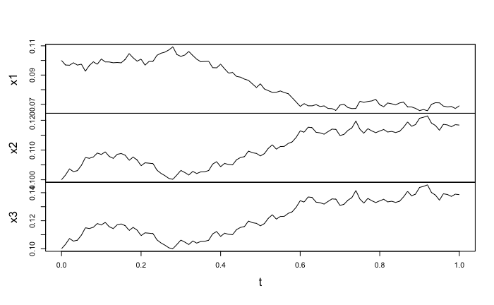

```r
sabr.mod.sim <- simulate(sabr.mod, true.parameter = list(mu=0.1,sigma=0.2,rho=-0.7))
plot(sabr.mod.sim)
```

```r
diff.coef.matrix
```

```
     [,1]                             [,2]
[1,] "f1(t,x1,x2,x3)"                 "0"
[2,] "f2(t,x1,x2,x3,rho, sig) * g(t)" "f3(t,x1,x2,x3,rho,sig)*g(t)"
[3,] "f2(t,x1,x2,x3,rho,sig)"         "f3(t,x1,x2,x3,rho,sig)"
```

```r
# Try adding an MLE here as per the heston book example ...
sabr.mod.sampling <- setSampling(Terminal=1, n=1000)
sabr.mod.yuima <- setYuima(model=sabr.mod, sampling = sabr.mod.sampling)
set.seed(123)
sabr.mod.yuima <- simulate(sabr.mod.yuima, xinit = list(0.1,0.1,0.1), true.parameter = list(mu=0.1,sigma=0.2,rho=-0.7))
param.init <- list(mu=0.1,sigma=0.2,rho=-0.7)
low.par <- list(mu=0.0,sigma=0.0,rho=-1)
upp.par <- list(mu=1,sigma=1,rho=1)
mle1 <- qmle(sabr.mod.sim, start = param.init, lower = low.par, upper = upp.par)
```

```
Error in yuima.stop("some named arguments in 'start' are not arguments to the supplied yuima model") :

YUIMA: some named arguments in 'start' are not arguments to the supplied yuima model
```

### 3D model reduced to SABR

Ok, so now a 3D model that gives some sort of output. I tried an MLE but it doesnt work, and im not sure how to handle t in g(t). So now lets make a copy and reduce it to be SABR…

```r
# Set correlation coefficient
rho <- -0.7
# Set diffusion coefficients for both processes
f1 <- function(x1, x2,alpha, beta) {
    ret <- x2 * x1^beta
    return(ret)
}
f2 <- function(x1, x2, alpha, beta) {
    ret <- alpha * x2
    return(ret)
}
# Create diffusion coefficient matrix as per Cholesky so correlation is achieved
diff.coef.matrix <- matrix(c("f1(x1, x2,alpha, beta)", "f2(x1, x2,alpha, beta) * rho", "0", "f2(x1, x2,alpha, beta)*sqrt(1-rho^2)"), 2, 2)
# Set up model
sabr.mod <- setModel(drift = c("", ""), diffusion = diff.coef.matrix, state.variable = c("x1", "x2"), solve.variable = c("x1", "x2"),xinit = c(0.1,0.1))
str(sabr.mod@parameter)
```

```
Formal class 'model.parameter' [package "yuima"] with 7 slots
  ..@ all      : chr [1:3] "alpha" "beta" "rho"
  ..@ common   : chr(0)
  ..@ diffusion: chr [1:3] "alpha" "beta" "rho"
  ..@ drift    : chr(0)
  ..@ jump     : chr(0)
  ..@ measure  : chr(0)
  ..@ xinit    : chr(0)
```

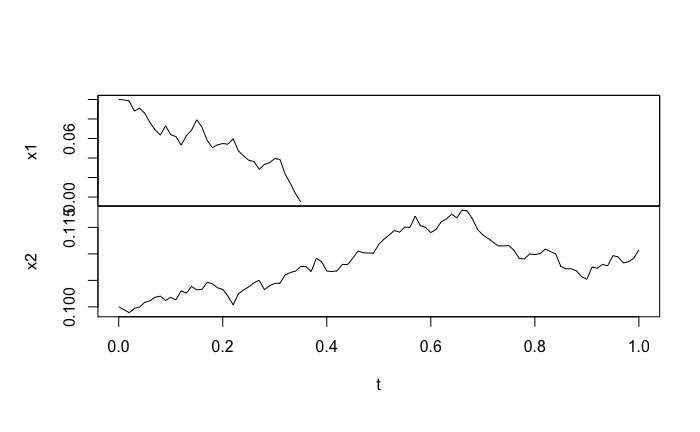

```r
# Generate simulated data & plot
sabr.mod.sim <- simulate(sabr.mod, true.parameter = list(alpha=0.1,beta=0.1))
plot(sabr.mod.sim)
```

```r
# Set sampling, create yuima object, set seed, pass yuima object some simulated data
sabr.mod.samp <- setSampling(Terminal=1, n=100)
sabr.mod.yuima <- setYuima(model=sabr.mod, sampling=sabr.mod.samp)
set.seed(123)
sabr.mod.yuima <- simulate(sabr.mod, true.parameter = list(alpha=0.1,beta=0.1), xinit =c(0.05,0.05) )
# Do a least squares estimate...
sabr.mod.lse <- lse(sabr.mod.yuima, start = list(alpha=0.1, beta=-0.1), lower = list(alpha=0.0, beta=-0.5), upper = list(alpha=0.8, beta=0.5),method="L-BFGS-B")
# Feed that output into the quasilog likelihood...
sabr.mod.lse
```

```
alpha  beta
  0.1  -0.1
```

```r
params=list(alpha = sabr.mod.lse[1],beta = sabr.mod.lse[2])
quasilogl(sabr.mod.yuima,param=params, print=TRUE)
```

```
[1] 1031.337
```

```r
# Do a qMLE: Bounds -0.5 <= beta <= 0.5, 0 < alpha <= 0.8 - seems sensible?
sabr.mod.mle <- qmle(sabr.mod.sim, start = list(alpha=0.1, beta=-0.1), lower = list(alpha=0.0, beta=-0.5), upper = list(alpha=0.8, beta=0.5),method="L-BFGS-B")
```

```
Error in solve.default(yB) :
  system is computationally singular: reciprocal condition number = 0
```

So, the LSE and QUASILOGL work which is interesting, but are presumable not optimised - its just a quasilogl for the parameters I fed it. The qMLE doesnt work due to that last error. Ive scoured the books, and docs, and all of the examples ive followed to the letter aside from the actual models and im not seeing anything out of line.